# Multivariate Classification of Mental Health Conditions

# Classifying Mental Health Conditions: Anxiety, PTSD, Depression, Bipolar, NaN

The goal of this notebook was to use a multivaraite classification to predict whether individuals have one of the five classes in the Mental Health Condition feature, which included: Anxiety, PTSD, Depression, Bipolar, and NaN (Which is none of the conditions). Two models were used, SVC (Support Vector Classifier) model, and Random Forest model as a more complex model. In order to train and test this multiclassification model, 12 features below were used from the 'Mental_Health_Lifestyle_Dataset'

Features:

- Country
- Age
- Gender
- Exercise Level
- Diet Type
- Sleep Hours
- Stress Level
- Mental Health Condition
- Work Hours per Week
- Screen Time per Day (Hours)
- Social Interaction Score
- Happiness Score

The Mental Health Lifestyle Dataset collected individual's self reported information which included multiple different countries.

Below is a link to the dataset for 'Mental_Health_Lifestyle_Dataset.csv'. Located on this webpage will be an explanation of the features involved. https://www.opendatabay.com/data/healthcare/9d475bde-164d-464f-bc27-13bfb0482fc0

## Data Exploration and Initialization

```python
# Import all libraries needed for working with data.
import pandas as pd
import numpy as np
import matplotlib.pyplot as plt
import seaborn as sns
from sklearn.model_selection import train_test_split, cross_val_score
from sklearn.preprocessing import StandardScaler
from sklearn.linear_model import LogisticRegression
from sklearn.svm import SVC
from sklearn.metrics import accuracy_score, classification_report
from sklearn.metrics import confusion_matrix
# import for Random Forest model
from sklearn.ensemble import RandomForestClassifier
```

```python
# Set up plotting style
plt.style.use('default')
plt.rcParams['figure.figsize'] = (10, 6)
plt.rcParams['font.size'] = 12
```

```python
# Import the dataset from google drive into this notebook.
# Note: If you have issues with having a space in the script, just change your space to a "\". Instead of "My Drive", do "My\Drive".
from google.colab import drive
drive.mount('/content/drive')
print('You have successfully mounted your drive :)')
```

```
You have successfully mounted your drive :)
```

```python
# Load the data from google drive into this notebook.
data = pd.read_csv('/content/drive/My Drive/MATH237_CSUF/Datasets_M237/Mental_Health_Lifestyle_Dataset.csv')
print('Good job, you loaded the dataset into this notebook!')
```

```
Good job, you loaded the dataset into this notebook!
```

```python
# Find amount of rows and columns in dataset.
print(f"There are {data.shape[0]} samples and {data.shape[1]} features in this dataset.")
```

```
There are 3000 samples and 12 features in this dataset.
```

```python
# summary of features in the dataset
data.info()
```

```
<class 'pandas.core.frame.DataFrame'>
RangeIndex: 3000 entries, 0 to 2999
Data columns (total 12 columns):
 #   Column                       Non-Null Count  Dtype
---  ------                       --------------  -----
 0   Country                      3000 non-null   object
 1   Age                          3000 non-null   int64
 2   Gender                       3000 non-null   object
 3   Exercise Level               3000 non-null   object
 4   Diet Type                    3000 non-null   object
 5   Sleep Hours                  3000 non-null   float64
 6   Stress Level                 3000 non-null   object
 7   Mental Health Condition      2405 non-null   object
 8   Work Hours per Week          3000 non-null   int64
 9   Screen Time per Day (Hours)  3000 non-null   float64
 10  Social Interaction Score     3000 non-null   float64
 11  Happiness Score              3000 non-null   float64
dtypes: float64(4), int64(2), object(6)
memory usage: 281.4+ KB
```

```python
data.head()
```

|  | Country | Age | Gender | Exercise Level | Diet Type | Sleep Hours | Stress Level | Mental Health Condition | Work Hours per Week | Screen Time per Day (Hours) | Social Interaction Score | Happiness Score |
| --- | --- | --- | --- | --- | --- | --- | --- | --- | --- | --- | --- | --- |
| 0 | Brazil | 48 | Male | Low | Vegetarian | 6.3 | Low | NaN | 21 | 4.0 | 7.8 | 6.5 |
| 1 | Australia | 31 | Male | Moderate | Vegan | 4.9 | Low | PTSD | 48 | 5.2 | 8.2 | 6.8 |
| 2 | Japan | 37 | Female | Low | Vegetarian | 7.2 | High | NaN | 43 | 4.7 | 9.6 | 9.7 |
| 3 | Brazil | 35 | Male | Low | Vegan | 7.2 | Low | Depression | 43 | 2.2 | 8.2 | 6.6 |
| 4 | Germany | 46 | Male | Low | Balanced | 7.3 | Low | Anxiety | 35 | 3.6 | 4.7 | 4.4 |

```python
# The unique values in Country column
data['Country'].unique()
```

```
array(['Brazil', 'Australia', 'Japan', 'Germany', 'India', 'Canada',
       'USA'], dtype=object)
```

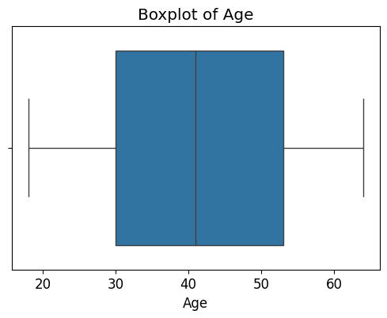

```
Mean Age: 41.22966666666667
Median Age: 41.0
Max Age: 64
Min Age: 18
```

```python
# The unique values in Age column
data['Age'].unique()

# Create the boxplot
plt.figure(figsize=(6, 4))
sns.boxplot(x=data['Age'])

# Labels and title
plt.xlabel('Age')
plt.title('Boxplot of Age')

# Show the plot
plt.show()

# Calculate statistics
age_mean = data['Age'].mean()
age_median = data['Age'].median()
age_max = data['Age'].max()
age_min = data['Age'].min()

# Print results
print(f"Mean Age: {age_mean}")
print(f"Median Age: {age_median}")
print(f"Max Age: {age_max}")
print(f"Min Age: {age_min}")
```

```python
# The unique values in Gender column
data['Gender'].unique()
```

```
array(['Male', 'Female', 'Other'], dtype=object)
```

```python
# The unique values in Exercise Level column
data['Exercise Level'].unique()
```

```
array(['Low', 'Moderate', 'High'], dtype=object)
```

```python
# The unique values in Diet Type column
data['Diet Type'].unique()
```

```
array(['Vegetarian', 'Vegan', 'Balanced', 'Junk Food', 'Keto'],
      dtype=object)
```

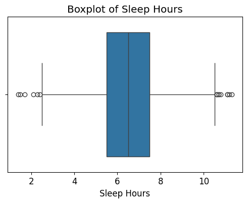

```
Mean Sleep Hours: 6.475933333333333
Median Sleep Hours: 6.5
Max Sleep Hours: 11.3
Min Sleep Hours: 1.4
```

```python
# The unique values in Sleep Hours column
data['Sleep Hours'].unique()

# Create the boxplot
plt.figure(figsize=(6, 4))
sns.boxplot(x=data['Sleep Hours'])

# Labels and title
plt.xlabel('Sleep Hours')
plt.title('Boxplot of Sleep Hours')

# Show the plot
plt.show()

# Calculate statistics
sleep_mean = data['Sleep Hours'].mean()
sleep_median = data['Sleep Hours'].median()
sleep_max = data['Sleep Hours'].max()
sleep_min = data['Sleep Hours'].min()

# Print results
print(f"Mean Sleep Hours: {sleep_mean}")
print(f"Median Sleep Hours: {sleep_median}")
print(f"Max Sleep Hours: {sleep_max}")
print(f"Min Sleep Hours: {sleep_min}")
```

```python
# The unique values in Stress Level column
data['Stress Level'].unique()
```

```
array(['Low', 'High', 'Moderate'], dtype=object)
```

```python
# The unique values in Mental Health Condition column
data['Mental Health Condition'].unique()
```

```
array([nan, 'PTSD', 'Depression', 'Anxiety', 'Bipolar'], dtype=object)
```

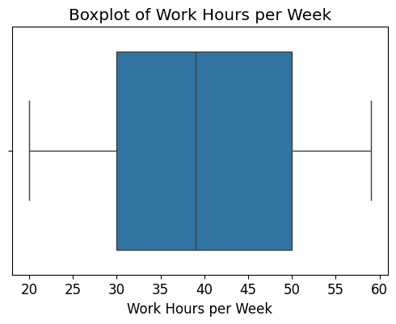

```
Mean Work Hours per Week: 39.46633333333333
Median Work Hours per Week: 39.0
Max Work Hours per Week: 59
Min Work Hours per Week: 20
```

```python
# The unique values in Work Hours per Week column
data['Work Hours per Week'].unique()

# Create the boxplot
plt.figure(figsize=(6, 4))
sns.boxplot(x=data['Work Hours per Week'])

# Labels and title
plt.xlabel('Work Hours per Week')
plt.title('Boxplot of Work Hours per Week')

# Show the plot
plt.show()

# Calculate statistics
work_mean = data['Work Hours per Week'].mean()
work_median = data['Work Hours per Week'].median()
work_max = data['Work Hours per Week'].max()
work_min = data['Work Hours per Week'].min()

# Print results
print(f"Mean Work Hours per Week: {work_mean}")
print(f"Median Work Hours per Week: {work_median}")
print(f"Max Work Hours per Week: {work_max}")
print(f"Min Work Hours per Week: {work_min}")
```

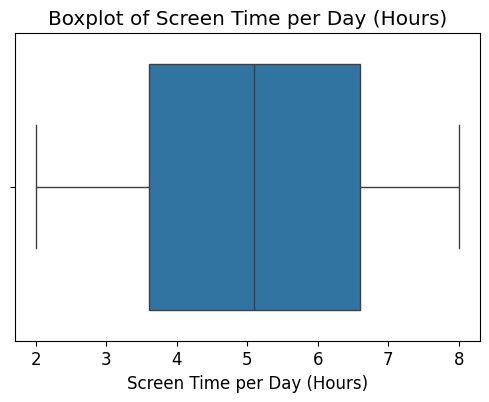

```
Mean Screen Time per Day (Hours): 5.089833333333333
Median Screen Time per Day (Hours): 5.1
Max Screen Time per Day (Hours): 8.0
Min Screen Time per Day (Hours): 2.0
```

```python
# The unique values in Screen Time per Day (Hours) column
data['Screen Time per Day (Hours)'].unique()

# Create the boxplot
plt.figure(figsize=(6, 4))
sns.boxplot(x=data['Screen Time per Day (Hours)'])

# Labels and title
plt.xlabel('Screen Time per Day (Hours)')
plt.title('Boxplot of Screen Time per Day (Hours)')

# Show the plot
plt.show()

# Calculate statistics
screen_mean = data['Screen Time per Day (Hours)'].mean()
screen_median = data['Screen Time per Day (Hours)'].median()
screen_max = data['Screen Time per Day (Hours)'].max()
screen_min = data['Screen Time per Day (Hours)'].min()

# Print results
print(f"Mean Screen Time per Day (Hours): {screen_mean}")
print(f"Median Screen Time per Day (Hours): {screen_median}")
print(f"Max Screen Time per Day (Hours): {screen_max}")
print(f"Min Screen Time per Day (Hours): {screen_min}")
```

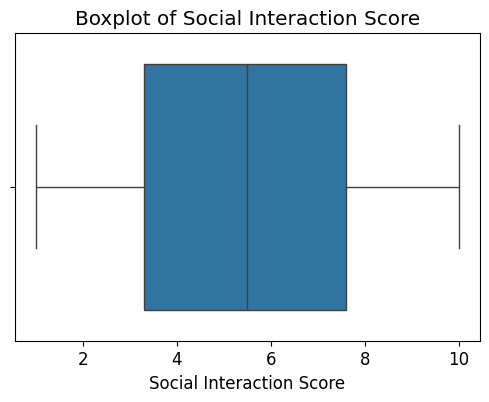

```
Mean Social Interaction Score: 5.470199999999999
Median Social Interaction Score: 5.5
Max Social Interaction Score: 10.0
Min Social Interaction Score: 1.0
```

```python
# The unique values in Social Interaction Score column
data['Social Interaction Score'].unique()

# Create the boxplot
plt.figure(figsize=(6, 4))
sns.boxplot(x=data['Social Interaction Score'])

# Labels and title
plt.xlabel('Social Interaction Score')
plt.title('Boxplot of Social Interaction Score')

# Show the plot
plt.show()

# Calculate statistics
social_mean = data['Social Interaction Score'].mean()
social_median = data['Social Interaction Score'].median()
social_max = data['Social Interaction Score'].max()
social_min = data['Social Interaction Score'].min()

# Print results
print(f"Mean Social Interaction Score: {social_mean}")
print(f"Median Social Interaction Score: {social_median}")
print(f"Max Social Interaction Score: {social_max}")
print(f"Min Social Interaction Score: {social_min}")
```

```python
# The unique values in Happiness Score column
data['Happiness Score'].unique()

# Calculate statistics
happiness_mean = data['Happiness Score'].mean()
happiness_median = data['Happiness Score'].median()
happiness_max = data['Happiness Score'].max()
happiness_min = data['Happiness Score'].min()

# Print results
print(f"Mean Happiness Score: {happiness_mean}")
print(f"Median Happiness Score: {happiness_median}")
print(f"Max Happiness Score: {happiness_max}")
print(f"Min Happiness Score: {happiness_min}")
```

```
Mean Happiness Score: 5.395066666666667
Median Happiness Score: 5.4
Max Happiness Score: 10.0
Min Happiness Score: 1.0
```

```python
# The unique values in Mental Health Condition column
data['Mental Health Condition'].value_counts()
```

| Mental Health Condition | count |
| --- | --- |
| Anxiety | 628 |
| PTSD | 624 |
| Depression | 580 |
| Bipolar | 573 |

**dtype:** int64

```python
# The total number of samples assigned with Mental health condition is 2405. The missing 595 samples are assigned NaN which means the individuals do not have any of the conditions.
data['Mental Health Condition'].isnull().sum()
```

```
np.int64(595)
```

## In this area of the notebook, the feature engineering portion was carried out in order to prepare the data for the multivariate classification model. Below were the planned changes to be made for columns in this dataset.

The following features didn't require any feature engineering:

unique measurements:

Brazil, Australia, Japan, Germany, India, Canada, USA

## Completed changes:

Needed to change this feature into multiple features and do one-hot encoding.

new features available after cahnges:

Country_Brazil, Country_Australia, Country_Japan, Country_Germany, Country_India, Country_Canada, Country_USA

measurements are now "0" (no) and "1" (yes)

- Gender

unique measurements have 3 options. Needed to one hot encode.

"Male, Female, Other"

## Completed changes:

Gender_Male, Gender_Female, Gender_Other

- Exercise Level

Needed to rename "Low", "moderate", and "High" to #'s like "1,2,3" respectively.

## Completed changes:

- Diet Type

Needed to one hot encode 'Vegetarian', 'Vegan', 'Balanced', 'Junk Food', 'Keto'

## Completed changes:

Diet Type_Vegetarian, Diet Type_Vegan, Diet Type_Balanced, Diet Type_Junk Food, Diet Type_Keto

- Sleep Hours

Nothing needed to change

- Stress Level

Needed to rename 'Low', 'High', 'Moderate' to #'s like "1,3,2"

## Completed changes:

The plan for making necessary changes was completed. Each feature will have a space below where changes were organized under their own section title of "Feature Engineering 'name'".

## Feature Engineering 'Country'

```python
# one-hot encode the Country column to be "Country_name".
data = pd.get_dummies(data, columns=['Country'], dtype=int)
print(data)
```

```
      Age  Gender Exercise Level   Diet Type  Sleep Hours Stress Level  \
0      48    Male            Low  Vegetarian          6.3          Low
1      31    Male       Moderate       Vegan          4.9          Low
2      37  Female            Low  Vegetarian          7.2         High
3      35    Male            Low       Vegan          7.2          Low
4      46    Male            Low    Balanced          7.3          Low
...   ...     ...            ...         ...          ...          ...
2995   57  Female       Moderate    Balanced          7.0         High
2996   27    Male            Low   Junk Food          7.1          Low
2997   42    Male       Moderate    Balanced          6.0         High
2998   25    Male           High        Keto          5.7          Low
2999   28  Female           High       Vegan          6.9         High

     Mental Health Condition  Work Hours per Week  \
0                        NaN                   21
```

[output cut: 51 more lines]

## Feature Engineering 'Gender'

```python
# one-hot encode the Gender column to be "Gender_name".
data = pd.get_dummies(data, columns=['Gender'], dtype=int)
print(data)
```

```
      Age Exercise Level   Diet Type  Sleep Hours Stress Level  \
0      48            Low  Vegetarian          6.3          Low
1      31       Moderate       Vegan          4.9          Low
2      37            Low  Vegetarian          7.2         High
3      35            Low       Vegan          7.2          Low
4      46            Low    Balanced          7.3          Low
...   ...            ...         ...          ...          ...
2995   57       Moderate    Balanced          7.0         High
2996   27            Low   Junk Food          7.1          Low
2997   42       Moderate    Balanced          6.0         High
2998   25           High        Keto          5.7          Low
2999   28           High       Vegan          6.9         High

     Mental Health Condition  Work Hours per Week  \
0                        NaN                   21
```

[output cut: 64 more lines]

## Feature Engineering 'Exercise Level'

```python
# Rename the Exercise Level column from 'Low', 'Moderate', and 'High' to '1','2','3', respectively.
data['Exercise Level'] = data['Exercise Level'].replace({
    'Low': 1,
    'Moderate': 2,
    'High': 3
})
print(data)
```

```
      Age  Exercise Level   Diet Type  Sleep Hours Stress Level  \
0      48               1  Vegetarian          6.3          Low
1      31               2       Vegan          4.9          Low
2      37               1  Vegetarian          7.2         High
3      35               1       Vegan          7.2          Low
4      46               1    Balanced          7.3          Low
...   ...             ...         ...          ...          ...
2995   57               2    Balanced          7.0         High
2996   27               1   Junk Food          7.1          Low
2997   42               2    Balanced          6.0         High
2998   25               3        Keto          5.7          Low
2999   28               3       Vegan          6.9         High

     Mental Health Condition  Work Hours per Week  \
0                        NaN                   21
```

[output cut: 64 more lines]

## Feature Engineering 'Diet Type'

```python
# one-hot encode the Diet Type to be "Diet Type_name".
data = pd.get_dummies(data, columns=['Diet Type'], dtype=int)
print(data)
```

```
      Age  Exercise Level  Sleep Hours Stress Level Mental Health Condition  \
0      48               1          6.3          Low                     NaN
1      31               2          4.9          Low                    PTSD
2      37               1          7.2         High                     NaN
3      35               1          7.2          Low              Depression
4      46               1          7.3          Low                 Anxiety
...   ...             ...          ...          ...                     ...
2995   57               2          7.0         High              Depression
2996   27               1          7.1          Low                     NaN
2997   42               2          6.0         High              Depression
2998   25               3          5.7          Low                 Anxiety
2999   28               3          6.9         High              Depression

      Work Hours per Week  Screen Time per Day (Hours)  \
0                      21                          4.0
```

[output cut: 64 more lines]

## Feature Engineering 'Stress Level'

```python
# Rename the 'Stress Level' column from 'Low', 'Moderate', and 'High' to '1','2','3', respectively.
data['Stress Level'].replace({
    'Low': 1,
    'Moderate': 2,
    'High': 3
}, inplace=True)
print(data)
```

```
      Age  Exercise Level  Sleep Hours  Stress Level Mental Health Condition  \
0      48               1          6.3             1                     NaN
1      31               2          4.9             1                    PTSD
2      37               1          7.2             3                     NaN
3      35               1          7.2             1              Depression
4      46               1          7.3             1                 Anxiety
...   ...             ...          ...           ...                     ...
2995   57               2          7.0             3              Depression
2996   27               1          7.1             1                     NaN
2997   42               2          6.0             3              Depression
2998   25               3          5.7             1                 Anxiety
2999   28               3          6.9             3              Depression

      Work Hours per Week  Screen Time per Day (Hours)  \
0                      21                          4.0
```

[output cut: 64 more lines]

## Feature Engineering 'Mental Health Condition'

```python
# fill the missing values in 'Mental Health Condition' column to 'None'
data['Mental Health Condition'] = data['Mental Health Condition'].fillna('NaN')
data.rename(columns={'NaN': 'None'}, inplace=True)
```

```python
data['Mental Health Condition'].value_counts()
```

| Mental Health Condition | count |
| --- | --- |
| Anxiety | 628 |
| PTSD | 624 |
| NaN | 595 |
| Depression | 580 |
| Bipolar | 573 |

**dtype:** int64

```python
# Lets see the list of columns before making this next new columns
print(data.columns.tolist())
```

```
['Age', 'Exercise Level', 'Sleep Hours', 'Stress Level', 'Mental Health Condition', 'Work Hours per Week', 'Screen Time per Day (Hours)', 'Social Interaction Score', 'Happiness Score', 'Country_Australia', 'Country_Brazil', 'Country_Canada', 'Country_Germany', 'Country_India', 'Country_Japan', 'Coun…
```

```python
#the new column names will be "name" not "Mental Health Condition"
#Note: one hot encoding was not necessary in order to make targets for multiclass model.
# data = pd.get_dummies(data, columns=['Mental Health Condition'], prefix='', prefix_sep='', dtype=int)
print(data)
print(data.columns.tolist())
```

```
      Age  Exercise Level  Sleep Hours  Stress Level Mental Health Condition  \
0      48               1          6.3             1                     NaN
1      31               2          4.9             1                    PTSD
2      37               1          7.2             3                     NaN
3      35               1          7.2             1              Depression
4      46               1          7.3             1                 Anxiety
...   ...             ...          ...           ...                     ...
2995   57               2          7.0             3              Depression
2996   27               1          7.1             1                     NaN
2997   42               2          6.0             3              Depression
2998   25               3          5.7             1                 Anxiety
2999   28               3          6.9             3              Depression

      Work Hours per Week  Screen Time per Day (Hours)  \
0                      21                          4.0
```

[output cut: 65 more lines]

## Preparing Multiclassification using SVC Model

- Target: Mental Health Condition

```python
# -------------------------------
# Step 2: Define features and target
# -------------------------------
features = ['Country_Brazil', 'Country_Australia', 'Country_Japan', 'Country_Germany',
    'Country_India', 'Country_Canada', 'Country_USA', 'Age',
    'Gender_Male', 'Gender_Female', 'Gender_Other',
    'Exercise Level',
    'Diet Type_Vegetarian', 'Diet Type_Vegan', 'Diet Type_Balanced',
    'Diet Type_Junk Food', 'Diet Type_Keto', 'Sleep Hours',
    'Stress Level',
    'Work Hours per Week', 'Screen Time per Day (Hours)',
    'Social Interaction Score', 'Happiness Score'
]

X = data[features]
y = data['Mental Health Condition']  # your target

# -------------------------------
# Step 3: Train/Validation/Test Split (60/20/20)
# -------------------------------

# First split: temp (40%) + train (60%)
X_train, X_temp, y_train, y_temp = train_test_split(
    X, y, test_size=0.40, random_state=42, stratify=y
)

# Second split: validation (20%) + test (20%)
X_val, X_test, y_val, y_test = train_test_split(
    X_temp, y_temp, test_size=0.50, random_state=42, stratify=y_temp
)

print("Train size:      ", X_train.shape)
print("Validation size: ", X_val.shape)
print("Test size:       ", X_test.shape)

# -------------------------------
# Step 4: Scale features
# -------------------------------
scaler = StandardScaler()

X_train = scaler.fit_transform(X_train)
X_val   = scaler.transform(X_val)
X_test  = scaler.transform(X_test)

# -------------------------------
# Step 5: Train SVC
# -------------------------------
model = SVC(gamma='auto')
model.fit(X_train, y_train)
```

```
Train size:       (1800, 23)
Validation size:  (600, 23)
Test size:        (600, 23)
```

```
SVC(gamma='auto')
```

## SVC: Multiclassification using Train Set

```
Training Accuracy: 0.49833333333333335

Training Classification Report:
               precision    recall  f1-score   support

     Anxiety       0.45      0.59      0.51       377
     Bipolar       0.52      0.39      0.44       344
  Depression       0.53      0.41      0.47       348
         NaN       0.53      0.55      0.54       357
        PTSD       0.49      0.54      0.51       374

    accuracy                           0.50      1800
   macro avg       0.50      0.50      0.49      1800
weighted avg       0.50      0.50      0.50      1800
```

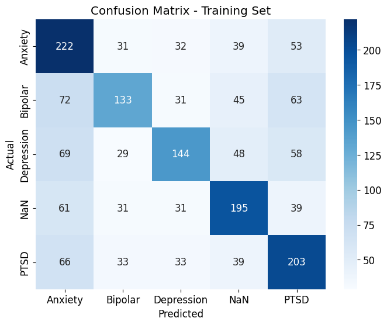

```python
# -------------------------------
# Step 6: Predictions & Evaluation on TRAIN set
# -------------------------------
y_pred = model.predict(X_train)

print("Training Accuracy:", accuracy_score(y_train, y_pred))
print("\nTraining Classification Report:\n", classification_report(y_train, y_pred))

cm = confusion_matrix(y_train, y_pred)

plt.figure(figsize=(8,6))
sns.heatmap(cm, annot=True, fmt='d', cmap='Blues',
            xticklabels=model.classes_, yticklabels=model.classes_)
plt.xlabel('Predicted')
plt.ylabel('Actual')
plt.title('Confusion Matrix - Training Set')
plt.show()
```

Conclusion: The multiclass model had roughly 50% precision. This means that the model still is unable to find a reliable pattern between the data. Nonetheless, the model is using training data so it was overfitting.

## SVC: Multiclassification using Validation Set

```
Validation Accuracy: 0.20333333333333334

Validation Classification Report:
               precision    recall  f1-score   support

     Anxiety       0.18      0.26      0.21       125
     Bipolar       0.22      0.17      0.19       115
  Depression       0.22      0.17      0.19       116
         NaN       0.24      0.20      0.22       119
        PTSD       0.18      0.22      0.20       125

    accuracy                           0.20       600
   macro avg       0.21      0.20      0.20       600
weighted avg       0.21      0.20      0.20       600
```

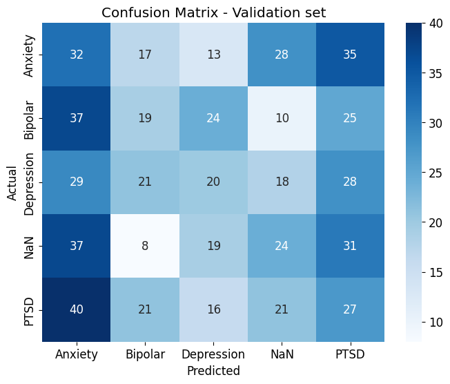

```python
# -------------------------------
# Step 6: Predictions & Evaluation on validation set
# -------------------------------
y_pred = model.predict(X_val)

print("Validation Accuracy:", accuracy_score(y_val, y_pred))
print("\nValidation Classification Report:\n", classification_report(y_val, y_pred))

cm = confusion_matrix(y_val, y_pred)

plt.figure(figsize=(8,6))
sns.heatmap(cm, annot=True, fmt='d', cmap='Blues',
            xticklabels=model.classes_, yticklabels=model.classes_)
plt.xlabel('Predicted')
plt.ylabel('Actual')
plt.title('Confusion Matrix - Validation set')
plt.show()
```

## SVC: Multiclassification using Test Set

```
Test Accuracy: 0.20166666666666666

Test Classification Report:
               precision    recall  f1-score   support

     Anxiety       0.18      0.29      0.23       126
     Bipolar       0.27      0.18      0.21       114
  Depression       0.20      0.16      0.17       116
         NaN       0.21      0.20      0.21       119
        PTSD       0.18      0.18      0.18       125

    accuracy                           0.20       600
   macro avg       0.21      0.20      0.20       600
weighted avg       0.21      0.20      0.20       600
```

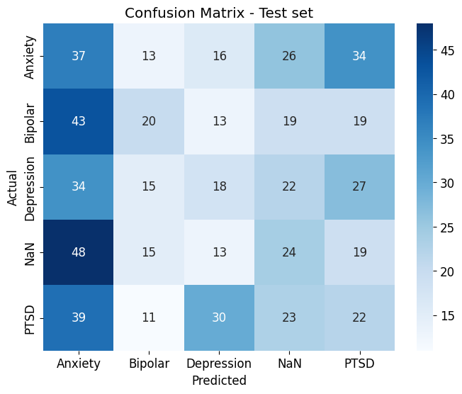

```python
# -------------------------------
# Step 6: Predictions & Evaluation on validation set
# -------------------------------
y_pred = model.predict(X_test)

print("Test Accuracy:", accuracy_score(y_test, y_pred))
print("\nTest Classification Report:\n", classification_report(y_test, y_pred))

cm = confusion_matrix(y_test, y_pred)

plt.figure(figsize=(8,6))
sns.heatmap(cm, annot=True, fmt='d', cmap='Blues',
            xticklabels=model.classes_, yticklabels=model.classes_)
plt.xlabel('Predicted')
plt.ylabel('Actual')
plt.title('Confusion Matrix - Test set')
plt.show()
```

Conclusion: The multiclass model had roughly 20% precision just like the validation set. This means that the model still is unable to find a pattern. The model is guessing randomly.

## Preparing the Multiclassification using Random Forest Model

- The Random Forest model was used in order to have a more complex model for the multiclassification since the SVC model performed poorly.
- The data is separated into 60% training set data, 20% Validation set data, and 20% test data.
- The Training set, Validation set, and Test set were all tested and displayed in a confusion matrix below to test for how well the model predicted the target.

```python
# Testing the training set

# --------------------------------
# Step 2: Define features and target
# --------------------------------

features = ['Country_Brazil', 'Country_Australia', 'Country_Japan', 'Country_Germany',
    'Country_India', 'Country_Canada', 'Country_USA', 'Age',
    'Gender_Male', 'Gender_Female', 'Gender_Other',
    'Exercise Level',
    'Diet Type_Vegetarian', 'Diet Type_Vegan', 'Diet Type_Balanced',
    'Diet Type_Junk Food', 'Diet Type_Keto', 'Sleep Hours',
    'Stress Level',
    'Work Hours per Week', 'Screen Time per Day (Hours)',
    'Social Interaction Score', 'Happiness Score'
]

X = data[features]
y = data['Mental Health Condition']  # multiclass target

# --------------------------------
# Step 3: Train / Validation / Test Split (60 / 20 / 20)
# --------------------------------

# First split → Train (60%) and Temp (40%)
X_train, X_temp, y_train, y_temp = train_test_split(
    X, y, test_size=0.40, random_state=42, stratify=y
)

# Second split → Validation (20%) and Test (20%)
X_val, X_test, y_val, y_test = train_test_split(
    X_temp, y_temp, test_size=0.50, random_state=42, stratify=y_temp
)

print("Train size:", X_train.shape)
print("Validation size:", X_val.shape)
print("Test size:", X_test.shape)

# --------------------------------
# Step 4: Scale numeric features
# --------------------------------
scaler = StandardScaler()
X_train = scaler.fit_transform(X_train)
X_val   = scaler.transform(X_val)
X_test  = scaler.transform(X_test)

# --------------------------------
# Step 5: Train BETTER MODEL (Random Forest)
# --------------------------------
model = RandomForestClassifier(
    n_estimators=100,
    max_depth=None,
    class_weight='balanced',  # important for mental health imbalance
)

model.fit(X_train, y_train)
```

```
Train size: (1800, 23)
Validation size: (600, 23)
Test size: (600, 23)
```

```
RandomForestClassifier(class_weight='balanced')
```

## Random Forest: Multiclassification using Train Set

```
VALIDATION ACCURACY: 1.0

VALIDATION Classification Report:
               precision    recall  f1-score   support

     Anxiety       1.00      1.00      1.00       377
     Bipolar       1.00      1.00      1.00       344
  Depression       1.00      1.00      1.00       348
         NaN       1.00      1.00      1.00       357
        PTSD       1.00      1.00      1.00       374

    accuracy                           1.00      1800
   macro avg       1.00      1.00      1.00      1800
weighted avg       1.00      1.00      1.00      1800
```

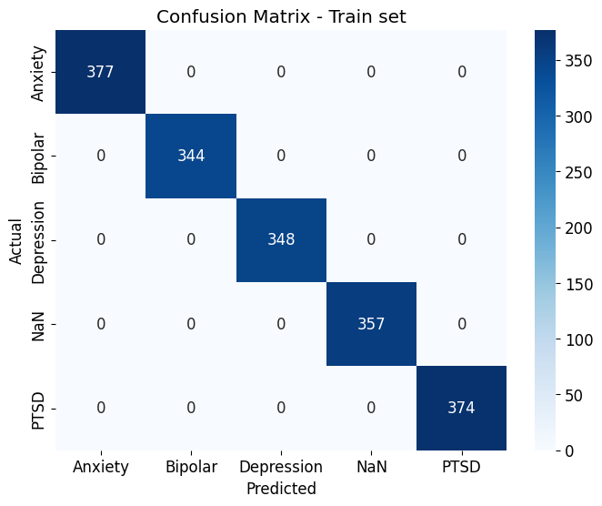

```python
# --------------------------------
# Step 6: Test Model (USE TRAIN SET)
# --------------------------------
y_pred_train = model.predict(X_train)

print("\nVALIDATION ACCURACY:", accuracy_score(y_train, y_pred_train))
print("\nVALIDATION Classification Report:\n", classification_report(y_train, y_pred_train))

cm = confusion_matrix(y_train, y_pred_train)

plt.figure(figsize=(8,6))
sns.heatmap(cm, annot=True, fmt='d', cmap='Blues',
            xticklabels=model.classes_, yticklabels=model.classes_)
plt.xlabel('Predicted')
plt.ylabel('Actual')
plt.title('Confusion Matrix - Train set')
plt.show()
```

Conclusion: The multiclass model overfitted, this is why the precision was 100%. Therefore the model cheated and failed at learning any pattern from the data.

## Random Forest: Multiclassification using Validation Set

```
VALIDATION ACCURACY: 0.2

VALIDATION Classification Report:
               precision    recall  f1-score   support

     Anxiety       0.17      0.21      0.19       125
     Bipolar       0.20      0.17      0.19       115
  Depression       0.22      0.19      0.20       116
         NaN       0.21      0.20      0.20       119
        PTSD       0.22      0.22      0.22       125

    accuracy                           0.20       600
   macro avg       0.20      0.20      0.20       600
weighted avg       0.20      0.20      0.20       600
```

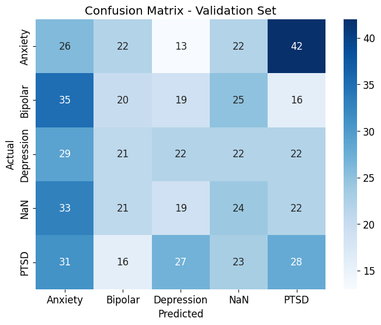

```python
# --------------------------------
# Step 6: Test Model (USE VALIDATION SET)
# --------------------------------
y_pred_val = model.predict(X_val)

print("\nVALIDATION ACCURACY:", accuracy_score(y_val, y_pred_val))
print("\nVALIDATION Classification Report:\n", classification_report(y_val, y_pred_val))

cm = confusion_matrix(y_val, y_pred_val)

plt.figure(figsize=(8,6))
sns.heatmap(cm, annot=True, fmt='d', cmap='Blues',
            xticklabels=model.classes_, yticklabels=model.classes_)
plt.xlabel('Predicted')
plt.ylabel('Actual')
plt.title('Confusion Matrix - Validation Set')
plt.show()
```

Conclusion: The multiclass model had roughly 20% precision just like the validation set. This means that the model still is unable to find a pattern. The model is guessing randomly.

## Random Forest: Multiclassification using Test Set

```
Test Accuracy: 0.19666666666666666

 Test Classification Report:
               precision    recall  f1-score   support

     Anxiety       0.20      0.28      0.23       126
     Bipolar       0.21      0.18      0.19       114
  Depression       0.21      0.20      0.20       116
         NaN       0.15      0.13      0.14       119
        PTSD       0.21      0.20      0.20       125

    accuracy                           0.20       600
   macro avg       0.20      0.20      0.19       600
weighted avg       0.20      0.20      0.19       600
```

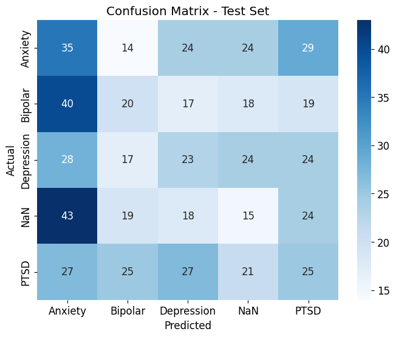

```python
# -------------------------------
# Step 6: Predictions & Evaluation on test set
# -------------------------------
y_pred = model.predict(X_test)

print("Test Accuracy:", accuracy_score(y_test, y_pred))
print("\n Test Classification Report:\n", classification_report(y_test, y_pred))

cm = confusion_matrix(y_test, y_pred)

plt.figure(figsize=(8,6))
sns.heatmap(cm, annot=True, fmt='d', cmap='Blues',
            xticklabels=model.classes_, yticklabels=model.classes_)
plt.xlabel('Predicted')
plt.ylabel('Actual')
plt.title('Confusion Matrix - Test Set')
plt.show()
```

Conclusion: The multiclass model had roughly 20% precision just like the validation set. This means that the model still is unable to find a pattern. The model is guessing randomly.

## Final preparation of Random Forest model

- The Random Forest model was used in order to have a more complex model for the multiclassification since the SVC model performed poorly.
- The data is separated into 80% training set data and 20% test data.
- This is the final preparation to do the random forest model multiclassification.

```
Train size: (2400, 23)
Test size: (600, 23)
Model training complete.
Test Accuracy: 0.20666666666666667

Test Classification Report:
               precision    recall  f1-score   support

     Anxiety       0.21      0.24      0.22       126
     Bipolar       0.17      0.16      0.16       114
  Depression       0.22      0.20      0.21       116
         NaN       0.20      0.19      0.20       119
        PTSD       0.23      0.24      0.24       125

    accuracy                           0.21       600
   macro avg       0.21      0.21      0.21       600
weighted avg       0.21      0.21      0.21       600
```

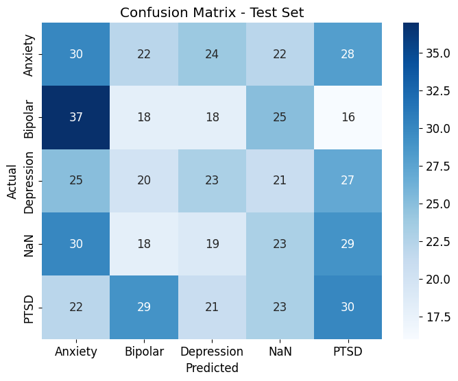

```python
# --------------------------------
# Step 3: Train / Test Split (80 / 20)
# --------------------------------

X_train, X_test, y_train, y_test = train_test_split(
    X, y, test_size=0.20, random_state=42, stratify=y
)

print("Train size:", X_train.shape)
print("Test size:", X_test.shape)

# --------------------------------
# Step 4: Scale numeric features
# --------------------------------
scaler = StandardScaler()
X_train = scaler.fit_transform(X_train)
X_test  = scaler.transform(X_test)

# --------------------------------
# Step 5: Train Random Forest Classifier
# --------------------------------
model = RandomForestClassifier(
    n_estimators=100,
    max_depth=None,
    class_weight='balanced',  # helps with class imbalance
)

model.fit(X_train, y_train)
print("Model training complete.")

# --------------------------------
# Step 6: Predictions & Evaluation on test set
# --------------------------------
y_pred = model.predict(X_test)

print("Test Accuracy:", accuracy_score(y_test, y_pred))
print("\nTest Classification Report:\n", classification_report(y_test, y_pred))

cm = confusion_matrix(y_test, y_pred)

plt.figure(figsize=(8,6))
sns.heatmap(cm, annot=True, fmt='d', cmap='Blues',
            xticklabels=model.classes_, yticklabels=model.classes_)
plt.xlabel('Predicted')
plt.ylabel('Actual')
plt.title('Confusion Matrix - Test Set')
plt.show()
```

Conclusion: The multiclass model had roughly 20% precision just like the previous confusion matrixes. This means that the model still is unable to find a pattern. The model is guessing randomly.

## Discussion

In conclusion this notebook aimed to perform a multivariate classification of Mental Health Condition as the target. While unsuccessful in this goal to provide a strong predicitive model, there was success in preparation of data from the "Mental_Health_Lifestyle_Dataset" by data cleaning, feature engineering, and steps taken to make attempt to build the model. One reason why the model did not work as expected could be because the target in the multiclassification was likely too difficult to actually predict given the features from the dataset. If given a more detailed dataset with more features, there may be a higher probability of the model working.

```python
# Convert this notebook to HTML
!jupyter nbconvert --to html --no-prompt "/content/drive/My drive/MATH237_CSUF/Project_2_M237/IT_Project2_MATH237_F25.ipynb" --output Project2_MATH237_F25_IanTroutt
```

[output not shown]

[output cut: 136 more lines]

[output not shown]